# Data Science Capstone

Jamin Wong

2022-07-19

# Abstract

In this project, I will use the data set provided by Coursera and Swift Key make a Shiny website. It will divided several parts: Understanding the problem

-Data acquisition and cleaning

-Exploratory analysis

-Statistical modeling

-Predictive modeling

-Creative exploration

-Creating a data product

-Creating a short slide deck pitching your product

The files in downloaded from: https://d396qusza40orc.cloudfront.net/dsscapstone/dataset/Coursera-SwiftKey.zip I will be using the files in final/en_US folder mainly

# Getting and Cleaning Data

## Load file

```r
fileB <- readLines("final/en_US/en_US.blogs.txt")
fileN <- readLines("final/en_US/en_US.news.txt")
fileT <- readLines("final/en_US/en_US.twitter.txt")
fileA <- rbind(fileB, fileN, fileT)
```

## Summary

```r
summ <- sapply(list(fileB, fileN, fileT), stri_stats_general)
wdctA <- sapply(list(fileB, fileN, fileT), wordcount)
rbind(c("blogs", "news", "twitter"), summ, wdctA)
```

```
##             [,1]        [,2]       [,3]
##             "blogs"     "news"     "twitter"
## Lines       "899288"    "77259"    "2360148"
## LinesNEmpty "899288"    "77259"    "2360148"
## Chars       "206824382" "15639408" "162096031"
## CharsNWhite "170389539" "13072698" "134082634"
## wdctA       "37334131"  "2643969"  "30373543"
```

## Remove punctuation, number and whitespace

```r
samp <- fileA %>% removePunctuation() %>% removeNumbers() %>% tolower()
```

This is to remove the punctuation, numbers and turn every word into lower case so that “the,” and “The” count as the same word.

```r
samp <- samp[sapply(samp, wordcount) > 3]
samp <- sample(samp, as.integer(round(length(samp) * 0.01)))
```

```r
wordcount(samp, count_fun = min)
```

```
## [1] 4
```

# Exploratory Analysis

In the exploratory analysis, I will be using n grams to find out the common phrases

## 1-grams (phrases with one word)

```r
ng1 <- ngram(samp, n=1)
pt1 <- get.phrasetable(ng1) %>% as.data.frame()
head(pt1, 20)
```

```
##    ngrams   freq        prop
## 1    the  103422 0.050872519
## 2     to   56561 0.027821939
## 3    and   53641 0.026385612
## 4      a   49691 0.024442636
## 5     of   44276 0.021779038
## 6     in   34807 0.017121307
## 7      i   30617 0.015060277
## 8   that   22122 0.010881649
## 9    for   21541 0.010595859
## 10    is   21336 0.010495021
## 11    it   18186 0.008945559
## 12    on   16086 0.007912585
## 13  with   15102 0.007428562
## 14   you   15059 0.007407411
## 15   was   13824 0.006799924
## 16    as   11172 0.005495424
## 17    at   11092 0.005456073
## 18  this   11015 0.005418197
## 19    my   10901 0.005362122
## 20    be   10894 0.005358678
```

### frequency plot 1-grams

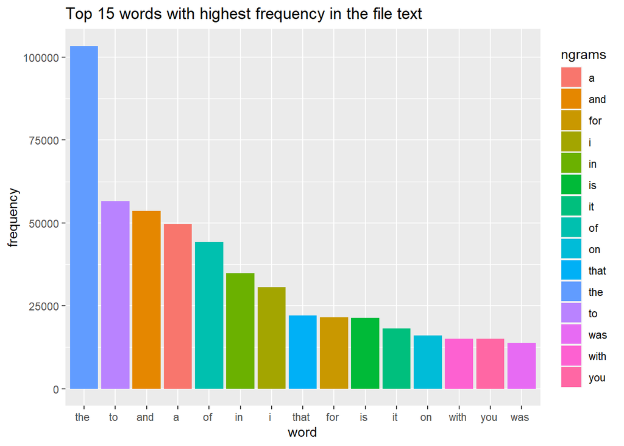

```r
g1 <- ggplot(pt1[1:15,], aes(x = reorder(ngrams, -freq), y=freq, fill=ngrams))
g1 <- g1 + geom_bar(stat="identity") + labs(x = "word", y = "frequency", title = "Top 15 words with highest frequency in the file text")
g1
```

“the”, “to”, and “and” have the three highest frequency in 1-grams.

## 2-grams (phrase with two words)

```r
ng2 <- ngram(samp, n = 2)
pt2 <- get.phrasetable(ng2) %>% as.data.frame()
head(pt2, 20)
```

```
##       ngrams freq         prop
## 1    of the  9653 0.0049069844
## 2    in the  8895 0.0045216643
## 3    to the  4576 0.0023261536
## 4    on the  4081 0.0020745264
## 5   for the  3893 0.0019789589
## 6     to be  3417 0.0017369901
## 7    at the  3030 0.0015402634
## 8   and the  2954 0.0015016297
## 9      in a  2564 0.0013033780
## 10 with the  2324 0.0011813769
## 11     is a  2133 0.0010842844
## 12   it was  2112 0.0010736093
## 13 from the  1942 0.0009871919
## 14    for a  1909 0.0009704168
## 15   with a  1796 0.0009129746
## 16    and i  1769 0.0008992495
## 17    it is  1765 0.0008972161
## 18   i have  1722 0.0008753576
## 19     of a  1698 0.0008631575
## 20    i was  1694 0.0008611242
```

### frequency plot 2-grams

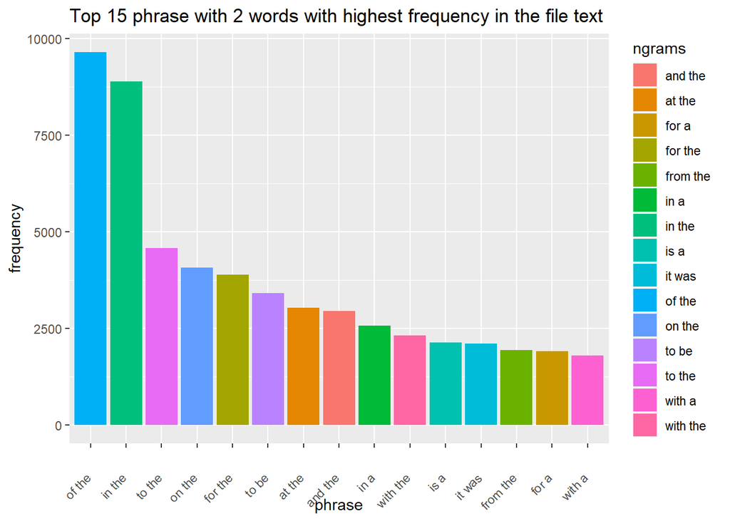

```r
g2 <- ggplot(pt2[1:15,], aes(x = reorder(ngrams, -freq), y=freq, fill=ngrams))
g2 <- g2 + geom_bar(stat="identity") + labs(x = "phrase", y = "frequency", title = "Top 15 phrase with 2 words with highest frequency in the file text") +
  theme(axis.text.x = element_text(angle = 45, vjust = 0.5, hjust=1))
g2
```

“of the”, “in the”, and “to the” have the three highest frequency in 2-grams.  
All of the top four contains the word “the”.

## 3-grams (phrase with three words)

```r
ng3 <- ngram(samp, n=3)
pt3 <- get.phrasetable(ng3) %>% as.data.frame()
head(pt3, 20)
```

```
##             ngrams freq         prop
## 1      one of the   698 0.0003670925
## 2        a lot of   635 0.0003339595
## 3         to be a   353 0.0001856499
## 4      as well as   347 0.0001824944
## 5     going to be   337 0.0001772352
## 6      the end of   321 0.0001688205
## 7      out of the   313 0.0001646131
## 8     some of the   304 0.0001598798
## 9        it was a   304 0.0001598798
## 10     be able to   282 0.0001483096
## 11    part of the   267 0.0001404208
## 12 thanks for the   266 0.0001398949
## 13      i want to   265 0.0001393689
## 14    a couple of   251 0.0001320061
## 15    the rest of   232 0.0001220136
## 16 the first time   231 0.0001214876
## 17      this is a   230 0.0001209617
## 18     end of the   211 0.0001109692
## 19      i have to   209 0.0001099174
## 20       i have a   205 0.0001078137
```

### frequency plot 3-grams

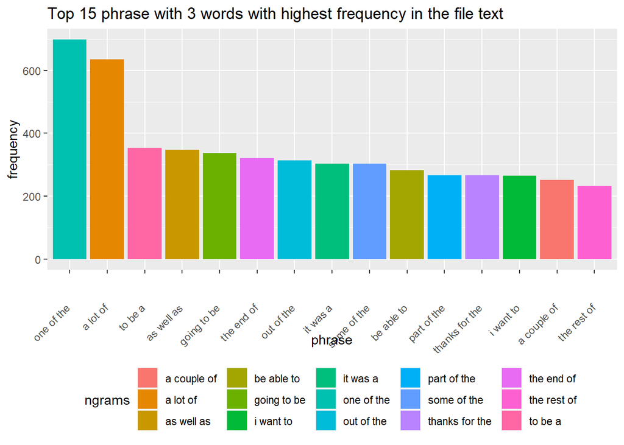

```r
g3 <- ggplot(pt3[1:15,], aes(x = reorder(ngrams, -freq), y=freq, fill=ngrams))
g3 <- g3 + geom_bar(stat="identity") +
  labs(x = "phrase", y = "frequency", title = "Top 15 phrase with 3 words with highest frequency in the file text") +
  theme(axis.text.x = element_text(angle = 45, vjust = 0.5, hjust=1),legend.position="bottom")

g3
```

### 4-grams

```r
ng4 <- ngram(samp, n=4)
pt4 <- get.phrasetable(ng4) %>% as.data.frame()
head(pt4, 20)
```

```
##                    ngrams freq         prop
## 1         the end of the   178 9.696785e-05
## 2          at the end of   156 8.498306e-05
## 3     for the first time   152 8.280401e-05
## 4        the rest of the   144 7.844590e-05
## 5       at the same time   104 5.665537e-05
## 6        one of the most    95 5.175250e-05
## 7         is going to be    87 4.739440e-05
## 8       in the middle of    81 4.412582e-05
## 9          is one of the    81 4.412582e-05
## 10         to be able to    80 4.358106e-05
## 11      when it comes to    80 4.358106e-05
## 12         i am going to    66 3.595437e-05
## 13 thanks for the follow    65 3.540961e-05
## 14        if you want to    65 3.540961e-05
## 15         going to be a    65 3.540961e-05
## 16       i would like to    60 3.268579e-05
## 17            a bit of a    54 2.941721e-05
## 18        the top of the    53 2.887245e-05
## 19        i dont want to    53 2.887245e-05
## 20        as well as the    53 2.887245e-05
```

### Total word count in the file

```r
wdct <- wordcount(samp)
wdct
```

```
## [1] 2031064
```

### average number of character in each word

```r
charPwd <- nchar(samp) / wdct
```

[output not shown]

## How many unique words is needed to cover 50% of the file text?

```r
count = 0
for (i in 1:nrow(pt1))
{
  count = count + pt1$freq[i]
  if (count >= 0.5 * wdct)
  {
    break
  }
}
i
```

```
## [1] 140
```

```r
i/nrow(pt1)
```

```
## [1] 0.001610621
```

It require 140 number of unique words to cover 50% of the file text, which 0.0016106 of the total number of unique words.

## Find non-English words

```r
#Load a English dictionary
data("GradyAugmented")

# Get all words that are in the dictionary
noEngIn <- sapply(pt1$ngrams, function(x) x %>% str_trim  %in% GradyAugmented)

nonEng <- pt1$ngrams[!noEngIn]
head(nonEng)
```

```
## [1] "im "   "dont " " "     "– "    "— "    "it’s "
```

Remove number of word start with capitalized data

```r
# Remove words that contain numbers
nonEng <- nonEng[!grepl(".*?[0-9]+.*?", str_trim(nonEng))]

# Remove words that is capitalized
# It is likely that such word is a special noun
nonEng <- nonEng[!grepl("^[A-Z]", str_trim(nonEng))]
head(nonEng)
```

```
## [1] "im "   "dont " " "     "– "    "— "    "it’s "
```

From the above list of character, we can see there is little to none words from foreign languages.

# Text Prediction

## Plan

### Prediction algorithm

I will create a prediction algorithm base on the n-grams words frequency. The frequency convert to probability.

1. Find all 3-grams phrase that contain the input word
2. Use the frequency of all the phrase to generate a probability distribution to determine which which is the next word.
3. For words that hasn’t appears in the n-grams, it will return a random 3 word phrase generated by the frequency (the higher the frequency in the training set, the higher the chance that the phrase is output)

### Shiny app

It will have a side panel which allow user to input word. It will also have the main panel which will produce output phrase from the prediction algorithm and the top three most probable phrase base on the probability distribution

# Prediction Model

```r
start.time = Sys.time()
pt3[grep("^me the",pt3$ngram),]
```

```
##                       ngrams freq         prop
## 8623            me the most     8 4.207364e-06
## 18825          me the whole     5 2.629603e-06
## 19521          me they were     5 2.629603e-06
## 26513           me they are     4 2.103682e-06
## 30454           me the same     4 2.103682e-06
## 52530            me the day     3 1.577762e-06
## 59320           me the kind     3 1.577762e-06
## 64928           me the best     3 1.577762e-06
## 69801        me the weakest     2 1.051841e-06
## 75627            me the tea     2 1.051841e-06
## 77200           me the next     2 1.051841e-06
## 77288           me the pain     2 1.051841e-06
## 100748           me the big     2 1.051841e-06
## 101033          me the link     2 1.051841e-06
```

[output cut: 125 more lines]

```r
pt3[grep("^-but the",pt3$ngram),]
```

```
## [1] ngrams freq   prop
## <0 rows> (or 0-length row.names)
```

```r
pt3[grep("^-at the",pt3$ngram),]
```

```
## [1] ngrams freq   prop
## <0 rows> (or 0-length row.names)
```

```r
pt3[grep("^-on my",pt3$ngram),]
```

```
## [1] ngrams freq   prop
## <0 rows> (or 0-length row.names)
```

```r
pt3[grep("^quite some",pt3$ngram),]
```

```
##                      ngrams freq         prop
## 16380      quite some time     6 3.155523e-06
## 1247013 quite sometime and     1 5.259205e-07
```

```r
pt3[grep("^little",pt3$ngram),]
```

```
##                                     ngrams freq         prop
## 1252                        little bit of    28 1.472577e-05
## 2283                     little more than    20 1.051841e-05
## 3578                      little bit more    15 7.888808e-06
## 13707                        little to no     6 3.155523e-06
## 16032                     little piece of     6 3.155523e-06
## 16692                       little out of     6 3.155523e-06
## 19095                       little over a     5 2.629603e-06
## 20757                    little by little     5 2.629603e-06
## 24503                       little of the     4 2.103682e-06
## 24830                        little or no     4 2.103682e-06
## 27903                 little worried that     4 2.103682e-06
## 29972                     little girl who     4 2.103682e-06
## 30956                       little on the     4 2.103682e-06
## 31500                      little guy and     4 2.103682e-06
```

[output cut: 1490 more lines]

```r
pt3[grep("^during the",pt3$ngram),]
```

```
##                               ngrams freq         prop
## 1464                 during the day    26 1.367393e-05
## 1904               during the first    22 1.157025e-05
## 4291                during the week    13 6.836967e-06
## 4918              during the summer    12 6.311046e-06
## 4920                during the past    12 6.311046e-06
## 9070                   during the s     8 4.207364e-06
## 11570               during the last     7 3.681444e-06
## 14323             during the second     6 3.155523e-06
## 14970             during the school     6 3.155523e-06
## 15585               during the game     6 3.155523e-06
## 15677               during the same     6 3.155523e-06
## 16495            during the hearing     6 3.155523e-06
## 17649             during the season     5 2.629603e-06
## 18283              during the final     5 2.629603e-06
```

[output cut: 243 more lines]

```r
pt3[grep("^must be",pt3$ngram),]
```

```
##                         ngrams freq         prop
## 2268                must be a    20 1.051841e-05
## 7202             must be done     9 4.733285e-06
## 7466              must be the     9 4.733285e-06
## 23678            must be made     4 2.103682e-06
## 28325         must be stopped     4 2.103682e-06
## 29093              must be at     4 2.103682e-06
## 34986            must be able     3 1.577762e-06
## 35713              must be an     3 1.577762e-06
## 44674            must be paid     3 1.577762e-06
## 47112         must be treated     3 1.577762e-06
## 51950        must be utilized     3 1.577762e-06
## 53086     must be accompanied     3 1.577762e-06
## 53541          must be pretty     3 1.577762e-06
## 56238              must be on     3 1.577762e-06
```

[output cut: 123 more lines]

```r
Sys.time() - start.time
```

```
## Time difference of 1.857788 mins
```